# Teensy-TAP manual

Version 1

Iris Adam

18 June 2018

## Summary

The Teensy-TAP is a micro-controller to trigger playback of sound in response to a bird singing. It is based in Teensy-TAF by Hamish Mehaffey. I changed the code to implement the following: - Running a timer (relative time since power-up at the moment) using the built in RTC. - Logging of events and their time stamp to a file on a micro-SD card using the built in SD-card port. - Playback of long sounds ~800ms. Code is adjusted to prevent triggering before PB ended and ideally to only trigger once per song type/motif/continuous(ish) unit of sound).

## Planned for v2:

### Hardware:

- Include an audio amplifier on the PCB.
- Include a 3V battery to retain time while disconnected from power

### Code:

- Implement random playback of sound from a selection of sounds (if not possible due to space issues, move arrays to SD and pre-buffer after each PB).
- Implement real time by syncing to a computer clock.

### Unclear:

- AUDIO_OUT_PIN is currently coded as 21 but the PCB connects 22. The two pins have different properties. Not sure which on should be chosen in v2.

## How it works (easy explanation)

### Hardware:

Everything runs on a Teensy board version 3.6 https://www.pjrc.com/store/teensy36.html. The periphery (mics and loud speaker) are connected to 5 pins on the board: - The power LED (part of the board) is on pin 13. - The audio-input from a microphone is read at pin A1 - The audio-input is mirrored to pin 21(code wise at least) to allow audio recording of what is going on. - A BNC connector is wired to pin 39 to allow triggering anything using TTL. - A connector to a speaker is wired to A21 to allow playback of sound.

### Code:

- Audio is continuously sampled and buffered. A sample (2*FFT_SIZE) is taken and the RMS is calculated. This doesn’t happen continuously, but about every 1ms.
- If the RMS is above the AMP_THRESHOLD (can be adjusted, typically is at 5000) and stays there for more than AMP_THRESHOLD_DURATION (currently 4 sampling loops (approx 4ms)) the FFT is calculated. This step makes sure that FFTs are only calculated if there was some sound.
- The FFT is calculated for the sample, normalized to the highest value within the FFT and then compared to the target FFT (also normalized) by computing the inner product DP (dot product however you want to call it).
- If DP is above the DP_THRESHOLD (currently at 1, not sure where this value came from) and was for as many times as asked by the TEMPLATE_MATCH_DURATION variable (currently at 1) the playback routine is triggered:
- The maximum value within the frequency window that can be set using FF_MIN and FF_MAX is identified.
- The FF is calculated more accurately by parabolic interpolation
- If this value is within the window set by FF_MIN and FF_MAX: + playback is triggered (play_wn()). + the BNC-pin is set to 5V + the time, FF, and HIT/CATCH variable is written to the serial port and a file on the SD-card (CSV) + a delay period is triggered

## Parameters to adjust and what they will do:

The following parameters can be used to adjust (I) the target and (II) the playback

### templt

1. FFT of the template. Length is FFT/2 So at the moment it is 256. Should be normalized to highest value within FFT. Can be derived by either letting the Teensy output the FFTs to serial or using the R script below. To use the Teensy: uncomment line (currently 193): //export_mags(); //For testing of FFT- will sent out 0:FFT_SIZE/2 from the calculated FFT magnitudes.

To generate a template in R d the following: Provide a wav-file of the syllable you want to target (target.wav):

```r
library(tuneR)
library(seewave)
#read in your target sound
target_wav<-readWave("target.wav")

#make spectrogram
spectro_target<-spectro(target_wav, wl=512)
```

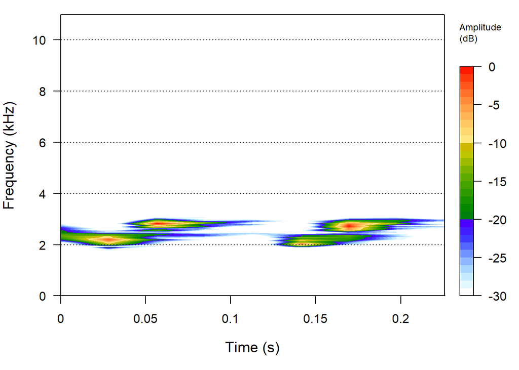

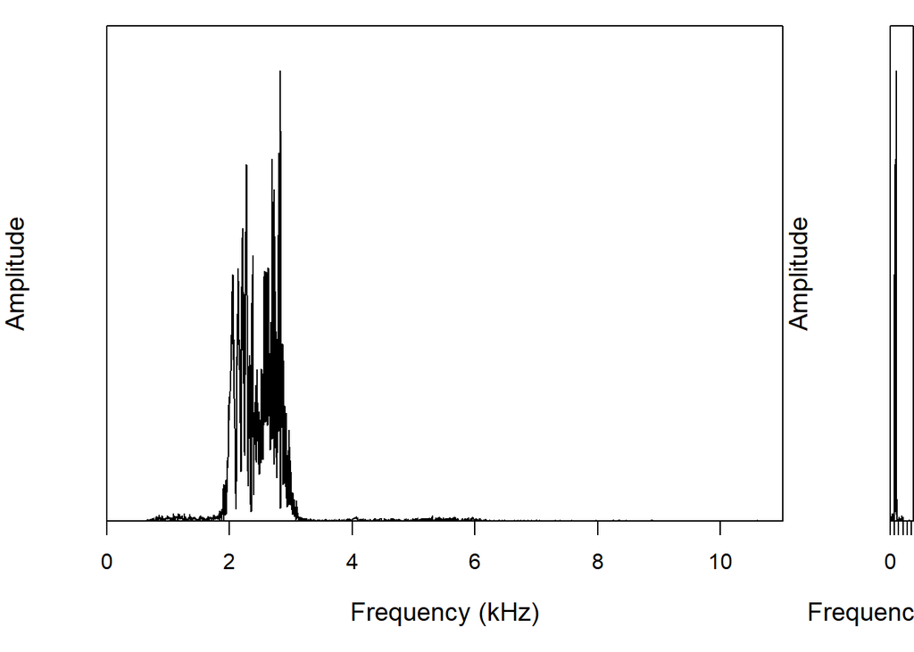

```
## $mean
## [1] 2570.828
##
## $sd
## [1] 834.9797
##
## $median
## [1] 2480.514
##
## $sem
## [1] 16.73309
##
## $mode
## [1] 2826.014
##
## $Q25
## [1] 2205.886
##
## $Q75
## [1] 2741.854
##
## $IQR
## [1] 535.9683
##
## $cent
## [1] 2570.828
##
## $skewness
## [1] 4.363667
##
## $kurtosis
## [1] 24.21381
##
## $sfm
## [1] 0.05983647
##
## $sh
## [1] 0.7312416
##
## $prec
##        x
## 4.427711
```

```r
#The FFTs are the columns of the @amp part of spectro_target (each column is one):
#to extract eg. the first one and write it to a file and copy paste it into the .ino file:
temp<-spectro_target[[3]]
write(temp[,1], "target.txt", ncolumns=nrow(temp), sep=",")

#properties of the entire freq spectrum. These can be used to adjust FF_MIN and FF_MAX for example
spec(target_wav)
specprop(spec(target_wav))
```

### FF_MIN and FF_MAX

Upper and lower boundary of the FFs triggering PB. Can be changed to adjust the frequency window

### AMP_THRESHOLD

Explains itself. To find a good value one can uncomment this line (currently 181): //Serial.println(RUNNING_AMP); Then the RMS is written to serial and one can use it to find a good threshold for the current setup.

### AMP_THRESHOLD_DURATION

Approximate length (in ms) of sound before anything is done. It is actually not in ms but in “time it takes to complete a loop”. Have to benchmark again after implementing writing to SD.

### TEMPLATE_MATCH_DURATION

How many samples should be similar to the target FFT before PB is triggered. This is probably always 1.

### DPTHRESH

Above which value the inner product between the template and the current sample is regarded “similar enough” to trigger the PB. Not sure what to use to adjust this… Experience will tell…

### FF_DISCARD

This is a filter to ignore low frequency stuff: FFs below this frequency are set to 0 to ignore them in the comparison to the target. Can be changed if necessary.